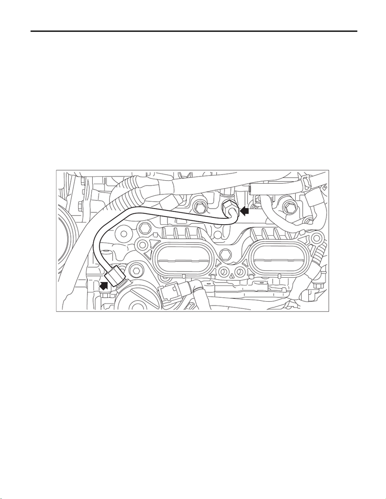

FU(w/o STI)-74

High Pressure Fuel Pump

FUEL INJECTION (FUEL SYSTEMS)

9. High Pressure Fuel Pump

A: REMOVAL

1. HIGH-PRESSURE FUEL PUMP

CAUTION:

• Be careful not to spill fuel.

• Catch the fuel from the pipes using a container or cloth.

1) Disconnect the ground terminal from battery sensor. <Ref. to NT-5, BATTERY, NOTE, Note.>

2) Remove the intake manifold. <Ref. to FU(w/o STI)-18, REMOVAL, Intake Manifold.>

3) Remove the fuel pump insulator. <Ref. to FU(w/o STI)-46, FUEL PUMP INSULATOR, REMOVAL, Fuel In-

sulator.>

4) Remove the fuel pipe insulator No. 1. <Ref. to FU(w/o STI)-47, FUEL PIPE INSULATOR NO. 1, REMOV-

AL, Fuel Insulator.>

5) Remove the fuel pipe insulator No. 2. <Ref. to FU(w/o STI)-47, FUEL PIPE INSULATOR NO. 2, REMOV-

AL, Fuel Insulator.>

6) Remove the high-pressure fuel delivery pipes.

FU-07933

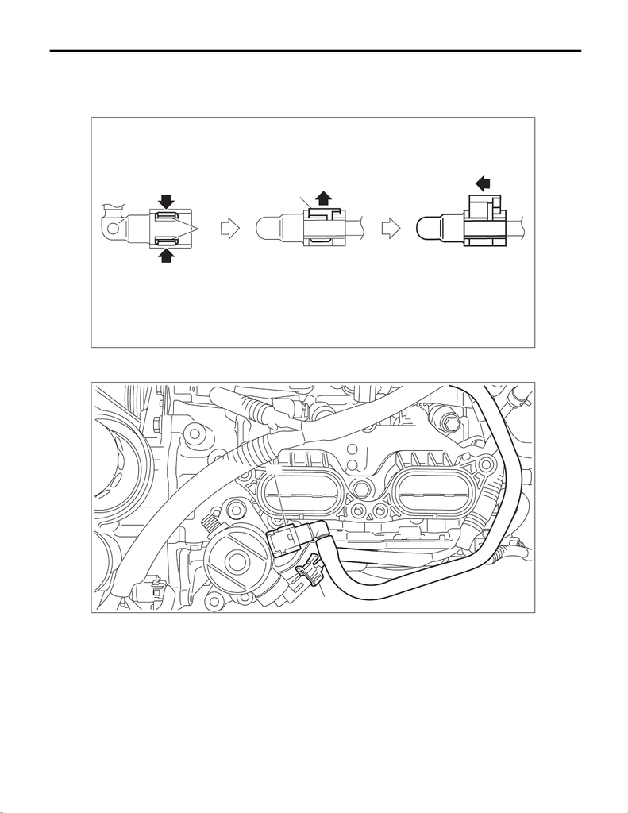

FU(w/o STI)-75

High Pressure Fuel Pump

FUEL INJECTION (FUEL SYSTEMS)

7) Remove the fuel delivery pipe (A) from the high-pressure fuel pump, and disconnect the connector (B)

from the high-pressure fuel pump.

NOTE:

Disconnect the quick connector as shown in the figure.

(a) Slider

FU-06059

(a)

(a)

FU-07961

(A)

(B)

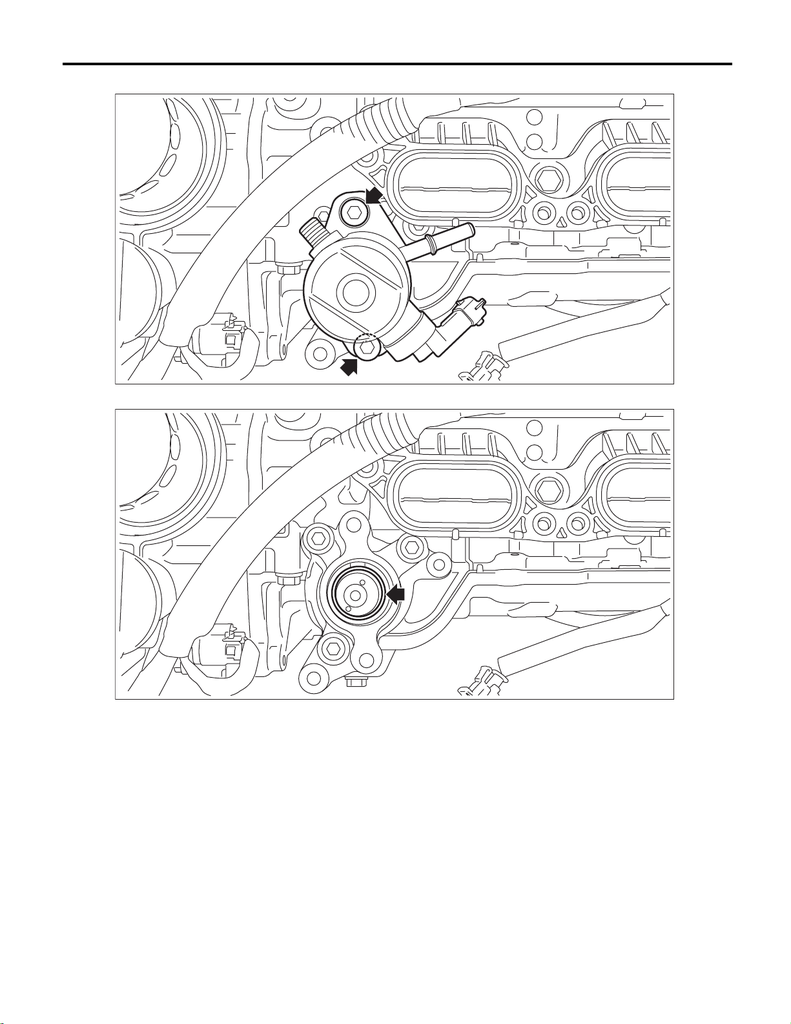

FU(w/o STI)-76

High Pressure Fuel Pump

FUEL INJECTION (FUEL SYSTEMS)

8) Using TORX PLUS

®

bit 40IP, remove the high-pressure fuel pump.

9) Remove the fuel pump lifter from the fuel pump case.

FU-07412

FU-07413

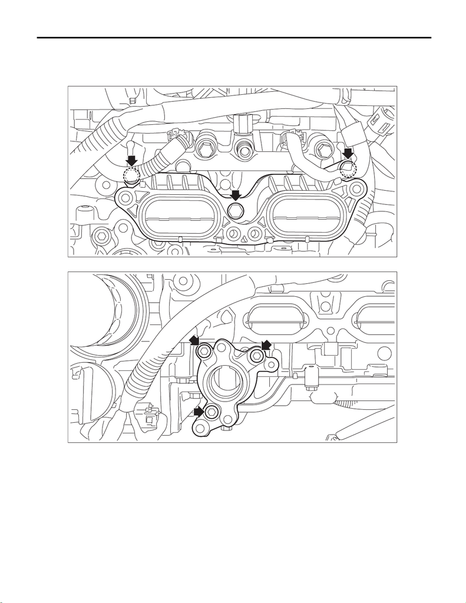

FU(w/o STI)-77

High Pressure Fuel Pump

FUEL INJECTION (FUEL SYSTEMS)

2. HIGH-PRESSURE FUEL PUMP CASE

1) Remove the high-pressure fuel pump. <Ref. to FU(w/o STI)-74, HIGH-PRESSURE FUEL PUMP, RE-

MOVAL, High Pressure Fuel Pump.>

2) Remove the air intake adapter LH from the cylinder head.

3) Remove the high-pressure fuel pump case from the cam carrier assembly LH.

FU-07934

FU-07417

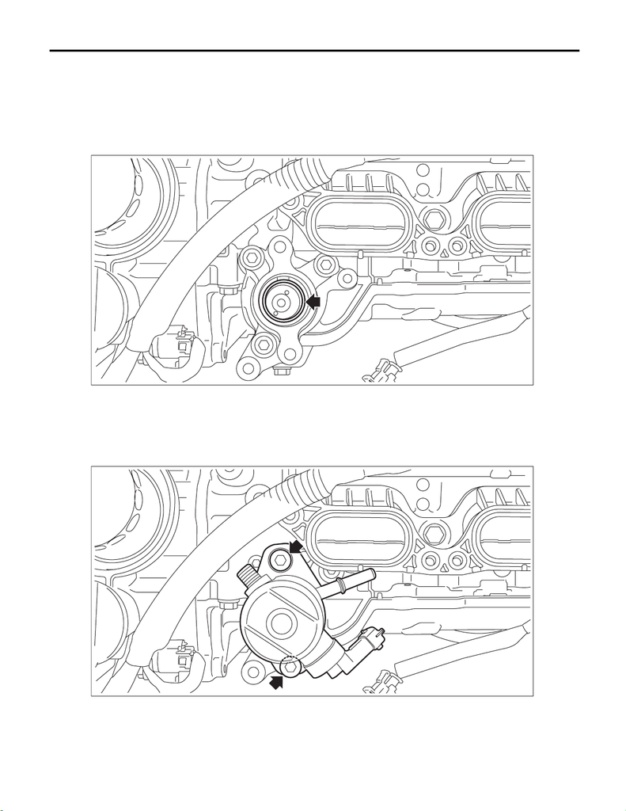

FU(w/o STI)-78

High Pressure Fuel Pump

FUEL INJECTION (FUEL SYSTEMS)

B: INSTALLATION

1. HIGH-PRESSURE FUEL PUMP

1) Install the fuel pump lifter to the high-pressure fuel pump case.

NOTE:

Apply engine oil to the side of the high-pressure fuel pump case and to the bottom surface of the fuel pump

lifter.

2) Using TORX PLUS

®

bit 40IP, install the high-pressure fuel pump.

NOTE:

Use new O-rings.

Tightening torque:

21 N·m (2.1 kgf-m, 15.5 ft-lb)

FU-07413

FU-07412

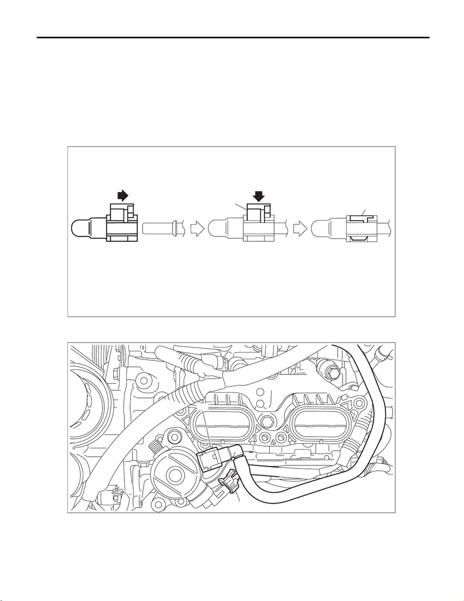

FU(w/o STI)-79

High Pressure Fuel Pump

FUEL INJECTION (FUEL SYSTEMS)

3) Connect the connector (B) to the high-pressure fuel pump, and install the fuel delivery pipe (A) to the high-

pressure fuel pump.

CAUTION:

• Check that there is no damage or dust on the quick connector. If necessary, clean the seal surface

of the pipe.

• When connecting the quick connector, make sure to insert it all the way in before locking the slider.

• When it is difficult to lock the slider, check that the connector is fully inserted.

• After locking the slider, check again that the quick connector is securely connected.

NOTE:

Connect the quick connector as shown in the figure.

(a) Slider

FU-06060

(a)

(a)

FU-07961

(A)

(B)

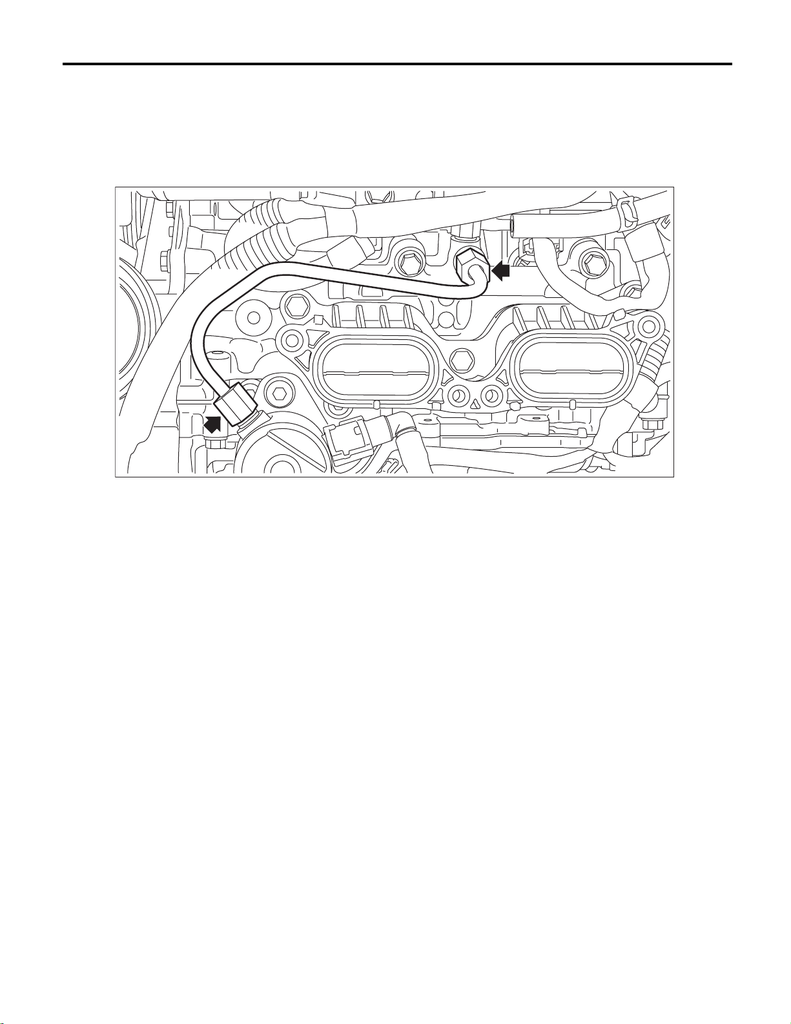

FU(w/o STI)-80

High Pressure Fuel Pump

FUEL INJECTION (FUEL SYSTEMS)

4) Temporarily tighten the high-pressure fuel delivery pipe by hand until it is seated, and tighten the flare nuts

on both ends.

CAUTION:

Always use a new high-pressure fuel delivery pipe.

Tightening torque:

25 N·m (2.5 kgf-m, 18.4 ft-lb)

5) Install the fuel pipe insulator No. 2. <Ref. to FU(w/o STI)-50, FUEL PIPE INSULATOR NO. 2, INSTALLA-

TION, Fuel Insulator.>

6) Install the fuel pipe insulator No. 1. <Ref. to FU(w/o STI)-49, FUEL PIPE INSULATOR NO. 1, INSTALLA-

TION, Fuel Insulator.>

7) Install the fuel pump insulator. <Ref. to FU(w/o STI)-49, FUEL PUMP INSULATOR, INSTALLATION, Fuel

Insulator.>

8) Install the intake manifold. <Ref. to FU(w/o STI)-29, INSTALLATION, Intake Manifold.>

9) Connect the ground terminal to battery sensor. <Ref. to NT-5, BATTERY, NOTE, Note.>

FU-07933

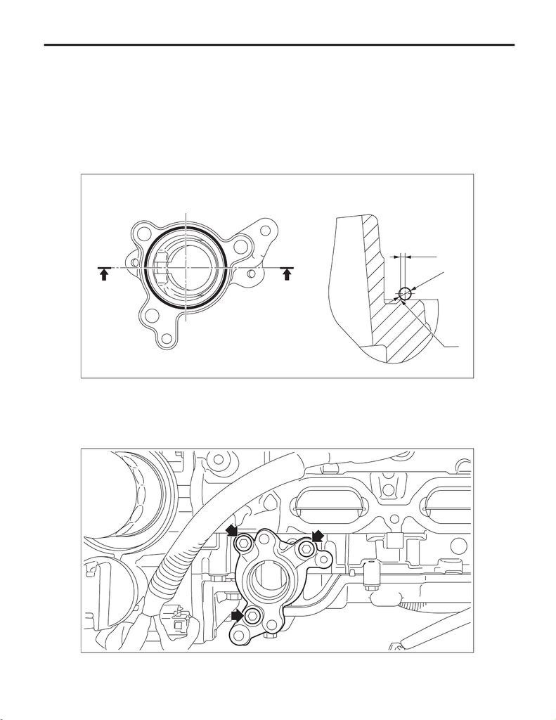

FU(w/o STI)-81

High Pressure Fuel Pump

FUEL INJECTION (FUEL SYSTEMS)

2. HIGH-PRESSURE FUEL PUMP CASE

1) Apply liquid gasket to the mating surfaces of fuel pump case, and install the high-pressure fuel pump case.

NOTE:

• Clean the mating surface of the high-pressure fuel pump case and cam carrier assembly LH.

• Install within 5 min. after applying liquid gasket.

Liquid gasket:

THREE BOND 1217G (Part No. K0877Y0100) or equivalent

Liquid gasket applying diameter:

3

±

1 mm (0.1181

±

0.0394 in)

2) Install the high-pressure fuel pump case to the cam carrier assembly LH.

Tightening torque:

19 N·m (1.9 kgf-m, 14.0 ft-lb)

(A) 1 mm (0.0394 in) (B) 3 mm (0.1181 in) (C) Chamfer edge

FU-07855

A

A

A - A

(A)

(B)

(C)

FU-07417

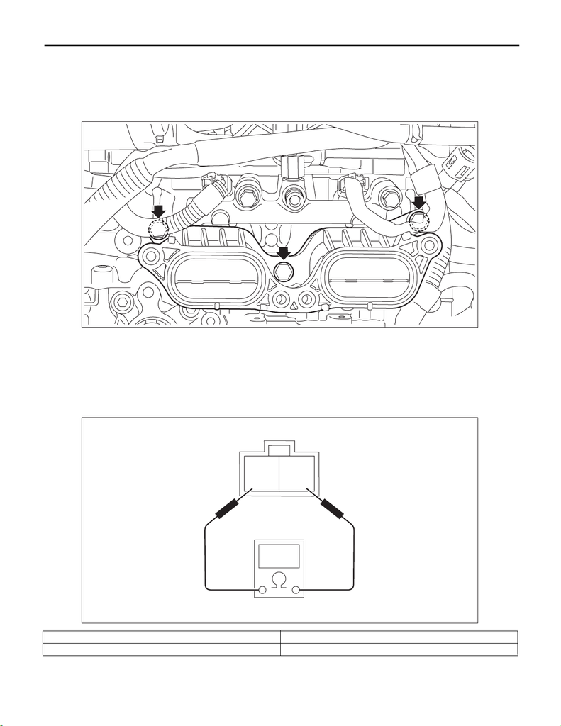

FU(w/o STI)-82

High Pressure Fuel Pump

FUEL INJECTION (FUEL SYSTEMS)

3) Install the air intake adapter LH to cylinder heads.

NOTE:

Use a new gasket.

Tightening torque:

25 N·m (2.5 kgf-m, 18.4 ft-lb)

4) Install the high-pressure fuel pump. <Ref. to FU(w/o STI)-78, HIGH-PRESSURE FUEL PUMP, INSTAL-

LATION, High Pressure Fuel Pump.>

C: INSPECTION

1. CHECK HIGH-PRESSURE FUEL PUMP

1) Check that the high-pressure fuel pump has no deformation, cracks or other damages.

2) Measure the resistance between high-pressure fuel pump terminals.

Terminal No. Standard

1 and 2 10±1 Ω (when 20°C (68°F))

FU-07934

FU-05950

2

1

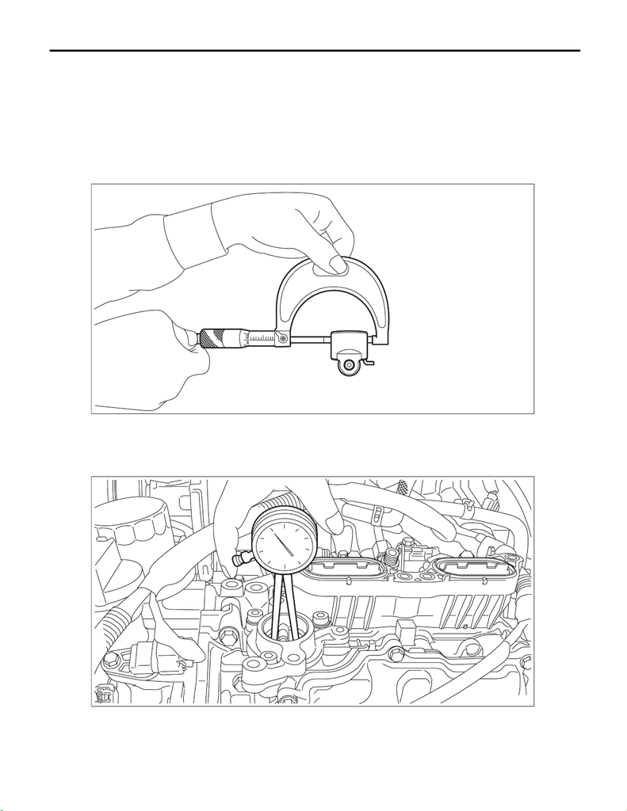

FU(w/o STI)-83

High Pressure Fuel Pump

FUEL INJECTION (FUEL SYSTEMS)

2. CHECK HIGH-PRESSURE FUEL PUMP CASE

1) Check that the high-pressure fuel pump case has no deformation, cracks or other damages.

2) Check the clearance between the fuel pump lifter and high-pressure fuel pump case bore. Check the

clearance between fuel pump lifter and high-pressure fuel pump case bore by measuring the outer diameter

of fuel pump lifter and the inner diameter of high-pressure fuel pump case bore respectively.

(1) Measure the outer diameter of fuel pump lifter with a micrometer.

NOTE:

• Measurement should be performed at a temperature of 20°C (68°F).

• Record the measured value.

(2) Using a caliper gauge, measure the inner diameter of high-pressure fuel pump case bore.

NOTE:

• Measurement should be performed at a temperature of 20°C (68°F).

• Record the measured value.

FU-07922

FU-07416

[figure not shown]

FU(w/o STI)-84

High Pressure Fuel Pump

FUEL INJECTION (FUEL SYSTEMS)

(3) Calculate the clearance between the fuel pump lifter and high-pressure fuel pump case bore. If it is not

within the standard, replace the fuel pump lifter and high-pressure fuel pump case as a set.

Clearance between fuel pump lifter and high-pressure fuel pump case bore:

Standard

0.065 — 0.134 mm (0.0026 — 0.0053 in)